# AWRL6432 Life Presence Detection Demo Users Guide

# Overview

This lab demonstrates the use of TI AWRL6432 mmWave sensors for Vehicle 2-row Child/Life Prescence Detection (CPD). This lab outputs a 3D point cloud over UART, which is then utilized by an Occupancy Detection State Machine in the accompanying MATLAB visualizer.

# Requirements

## Hardware Requirements

| Item | Details |
| --- | --- |
| AWRL6432 Evaluation Board | [AWRL6432 ES1.0 Evaluation Board](https://www.ti.com/tool/AWRL6432BOOST) |
| Computer | PC with Windows 10. If a laptop is used, please use the ‘High Performance’ power plan in Windows. |
| Micro USB Cable | Due to the high mounting height of the EVM, a 15ft+ cable or USB extension cable is recommended. |

## Additional Software Requirements

| Tool | Version | Download Link |
| --- | --- | --- |
| MATLAB Runtime | 2019a (9.6) | Exact version required. https://www.mathworks.com/products/compiler/matlab-runtime.html |

# Quickstart

## 1. Follow xwrL64xx/14xx MCU+ SDK

Follow the steps from the SDK, which can be found [here](https://www.ti.com/tool/MMWAVE-L-SDK)

- Run calibration
- Flash demo binary
- Configure the EVM to functional mode.

## 2. Mount the EVM and Create Test Environment

Mount the sensor at the desired location securely so that the sensor is stable during runtime. Update the desired configuration file so that it reflects the device’s location. More information on mounting can be found in the section below.

## 3. Launch the Visualizer

> 🛑 *MATLAB Runtime Version R2019a (9.6) Required*  
> **Exact version** [R2019a (9.6)](https://www.mathworks.com/products/compiler/matlab-runtime.html) required.
1. Launch the visualizer executable located at `<PACKAGE_LOCATION>\tools\visualizers\InCabin_LifePresenceDetection_GUI\`
2. Double click to launch **AWRL6432_LifePresenceDetection_visualizer.exe**.
3. A black console window will appear. After 30-60sec, a configuration window will appear as shown below.

## 4. Config Visualizer

[figure not shown]

1. Select the EVM Control and Data COM ports using the respective dropdowns.
2. You should see the Chirp configuration file automatically selected in the Configuration dialogue. But if the configuration file is not the correct one, browse to select a file provided in the config_file directory: `<PACKAGE_LOCATION>\tools\visualizers\InCabin_LifePresenceDetection_GUI\config_file`
3. Select **Real Demo** mode and press **Go!** to start the Visualizer.
4. Select **Index for recording file** if users plan to record the point cloud for future playback
5. The Visualizer window will appear as shown below and after several seconds, the visualizer should start showing the point cloud and occupancy decisions in their respective panels:

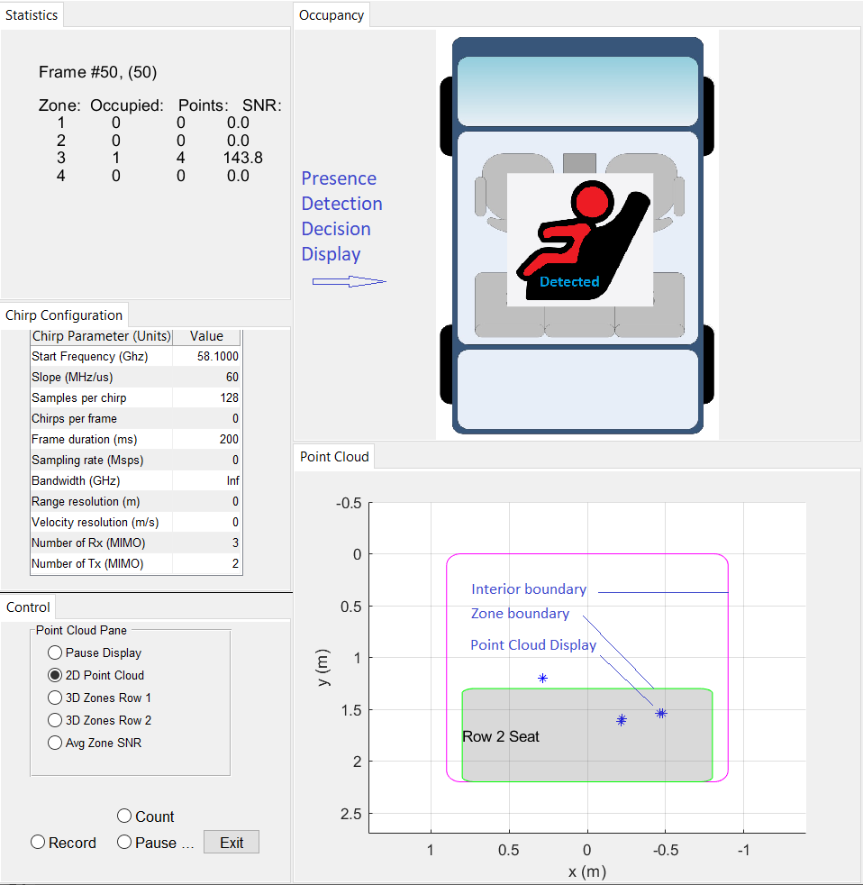

## 5. Understand the Visualizer

The Visualizer window is divided into five panels as shown in the annotated picture above:

1. **Statistics**: This section prints real-time information from the target: Frame number, both processed and (target), and a Zone table that displays the occupancy state, number of detections in the zone, and average SNR of the detections. When the Count button is clicked, the Points column becomes the “Frame” count (total number of frames that have been counted), and the SNR column becomes “Count” - the number of frames with positive occupancy state.
2. **Chirp Configuration**: This panels shows the static chirp configuration loaded at startup time.
3. **Control**: This panel provides an Exit button, a Record button (saves frame by frame point cloud and occupancy data). In addition, there are two sub-panels, which independently allows either the Occupancy Display to be paused, or selection/pausing of a display in the Point Cloud panel.
4. **Occupancy**: This panel pictorally displays the output of presence detection. The interior of the car will declair to be occupied if any of the defined zone is occupied.
5. **Point Cloud**: This panel can display one of several displays: “2D Point Cloud” shows and overhead view of the detected points, along with the zone boundaries when that zone decision is positive.

## 6. Re-playing previously saved output

As described in the previous section, the AWRL6432_LifePresenceDetection_visualizer can save the EVM UART output (point cloud information) in files named **fHistRT_`xxxx`.mat** where each file can contain up to 1000 frames of information. These saved fHist files can be re-played offline by running `AWRL6432_LifePresenceDetection_visualizer.exe` as shown below:

1. Navigate to `<PACKAGE_LOCATION>\tools\visualizers\InCabin_LifePresenceDetection_GUI\`
2. Copy the previously saved **fHistRT_xxxx.mat** files to the directory above
3. Launch the same visualizer **AWRL6432_LifePresenceDetection_visualizer.exe**, select the mode as **Playback** instead of **Real Demo** and select the preferred file index for the recorded file, and and press **Go!** to start the playback as shown in the figure below. In playback mode, the port numbers are no longer relevant, but a matching chirp configuration is still needed.

[figure not shown]

# Algorithm Overview

This demo can be viewed as two pieces: the device running the radar code and the host running the visualizer. The device code is the same demo as xwrL64xx/14xx MCU+ SDK OOB Demo, and information related to that part of the algorithm can be viewed in the SDK OOB documentation.

In order to increase performance of detection of nearly-static objects such as people/baby sitting still in the vehicle, this lab uses minor mode for detection, i.e., mutliple frames are used to generate range-Azimuth heatmap, rather than a single frame. By using a sliding window of multiple frames, there is a finer granularity of detection with respect to time.

After receiving the point cloud data from the radar device through UART, the visualizer will map the point cloud to different zones. Occupancy detection logic is then run for each zone to determined whether a zone is occupied. Finally, the presence detection is declared if any zone is occupied.

## Zone Mapping

After the point cloud is sent to host through UART. Inside visualizer, the point cloud is first transformed into car coordination. Then mapped to different zones. Each zone is defined through a sequence of cuboids using `cuboidDef` CLI command. The details can be found in the high accuracy VOD demo user’s guide

This zone mapping idea has been reused for all the in-cabin sensing demo, including localization, intruder detection, presence detection and etc.

For different application, users may need to define different zones. For in-cabin localization, a common practice is to define each seat as one zone. For presence detection demo, users can define the entire interior of car (including footwear region) as one zone. However with overhead mounting, we observe some false detection right under the sensor, which is caused by the strong floor reflection, we call it, **static leakage**. This type of false detection can be controlled through CFAR threshold adjustment based on angle and distance, which is however not yet supported in the current target code. Therefore, in our example, we define different zones and apply different detection threshold in the state machine to help with this problem.

## Occupancy Detection State Machine

After zone mapping, the Occupancy Detection State Machine is running to determine the occupancy status for each zone using a number of factors that can be configured by the `occStateMach` CLI command. The general idea is that a zone can be detected as occupied only if the total number and quality (average SNR) of the detected point cloud within the zone are higher than the pre-determined threaholds. The occupacy state machine is shown in the following figure

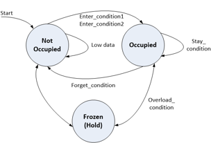

The `occStateMach` CLI holds the thresholds for enter-condition1, enter-condition2, stay-condition, forget-condition, and overload condition.

Users can define same or different zoneType for each zone through `zoneNeighDef` CLI. By introduce zoneType, the system can have multiple sets of occupancy detection thresholds. For example, second-row middle seat often experience stronger SNR and higher rate of false detection. Therefore, it makes sense to use a higher set of thresholds for the second row footwear region; the first row footwear may experience weaker SNR and higher rate of miss detection. Therefore, users can consider to use a lower set of thresholds to cover first row footwear. Note that the occupancy detection state machine is reused for all the in-cabin sensing demo, and therefore, could have been an over-design for the presence detection. For example, the overload condition logic is not really needed for presence detection. Therefore, users should program a big value for **overload condition**, so that overload condition will never be triggered.

Users can find the detail definition of each parameter of `occStateMach` and `zoneNeighDef` at CLI list session.

# EVM Mounting and Coordinate Transforms

The detected point cloud is all relative to the sensor. In order to make occupancy decision for each seat in the car, we need to transform the point cloud from sensor coordinates to the car coordinates. There are different position and different mounting angle that can be considered for mounting the device. To give the full flexibility, “sensorPosition” CLI is used to indicate the mounting offset in (x, y, z) and mounting rotation angle in y-z plane, x-y plane and x-z plane. Based on these offsets and tilting angles, the visualizer will transform the point cloud from the sensor coordinate to the car coordinate. The car coordinate is plotted in the left figure below. Here we provide one example:

- when the sensor is mounted around the center of the roof facing downward, then sensor position should be programmed as: `sensorPosition 0 1.2 1.2 90 -90 0`

  This indicates the sensor is mounted at (x = 0, y = 1.2m, z = 1.2m) and rotated 90 degree clockwise in y-z domain to facing the floor. In addition 90 degree anti-clockwise rotation in x-y plane to use the better FOV in azimuth to cover the depth of the car. Please referred to the figure below to help understanding.

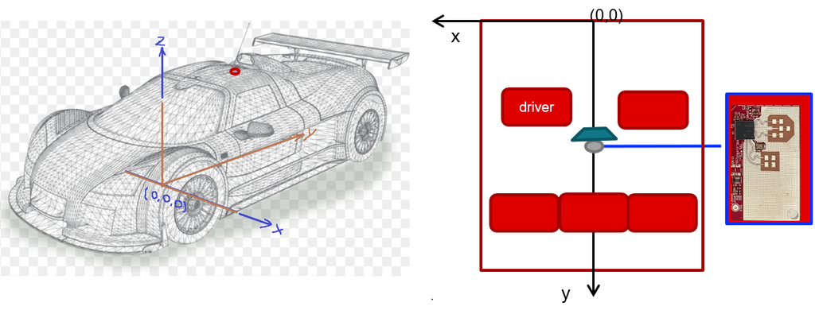

Users can find more mounting examples in the setup guide

# Demo Specific Configuration File Parameters

In addition to the standard xwrL64xx MCU+ SDK CLI commands (please refer to the [SDK’s user guide](https://www.ti.com/tool/MMWAVE-L-SDK) for these commands), there are some additional commands that are specific to this demo visualizer:

[output not shown]

# Performance Tuning

The key items to focus on for tuning are as follows:

- **Proper mounting** - Ensure that all FOV and resolution constaints from the device are accounted for.
- **Point Cloud Tuning** - Users can adjust CFAR detection threshold in cfarCfg CLI to trade off between number of detected points vs false detection ratio. Lower “K0” results in richer point cloud but higher false detection ratio.  
  cfarCfg 2 8 2 3 0 `9.0` 0 0.9 0 1 1 1
- **Accurate zone definition** - Ensuring the zones align with the physical space of the vehicle. This is described in further detail in the section zone mapping.
- **occStateMach** - All the parameters in the occStateMach affect how the occupancy state machine moves between states. They may need to be adjusted depending on the number of points and their SNR that is observed in the specific environment. These parameters are further defined in the parameter list.

# Need More Help?

- Search for your issue or post a new question on the [mmWave E2E forums](https://e2e.ti.com/support/sensor/mmwave_sensors/f/1023)
- See the SDK for more documentation on various algorithms used in this demo. Start at `<mmWave_sdk_install_dir>/docs/mmwave_sdk_module_documentation.html`